# California Cetaceans

Bri Baker

2/19/2021

## Summary

The following is a cetacean species richness map for the coastal waters of California. Richness is calculated using subsetted AquaMaps data that predicts probability of species occurrence of 35 cetacean species that can be found in the California Bight based on variables like relative environmental suitability, including species preferences for water temperature, depth, salinity, and distance to land (Kaschner et al., 2016). Map extent is 125° W to 115°W and 32°N to 38°N.

```r
#load data from file and convert to raster in a stack
ca_cet <- list.files(path = here("part2_data/ca_cetaceans"),
                     full.names = TRUE) %>%
  raster::stack()
```

```r
# make basemap of coastline in defined area
coastline <- ne_coastline(scale = 10,
                        returnclass = "sf"
                        )
```

```r
# define presence/absence in tribble
presence <- tribble(~from, ~to, ~value,
                    0, 0.6, 0,
                    0.6, 1, 1)

# reclass rasters to presence/absence
ca_cet_present <- reclassify(ca_cet, presence)

# calculate richness
ca_cet_rich <- sum(ca_cet_present, na.rm = TRUE)
```

## Species Richness

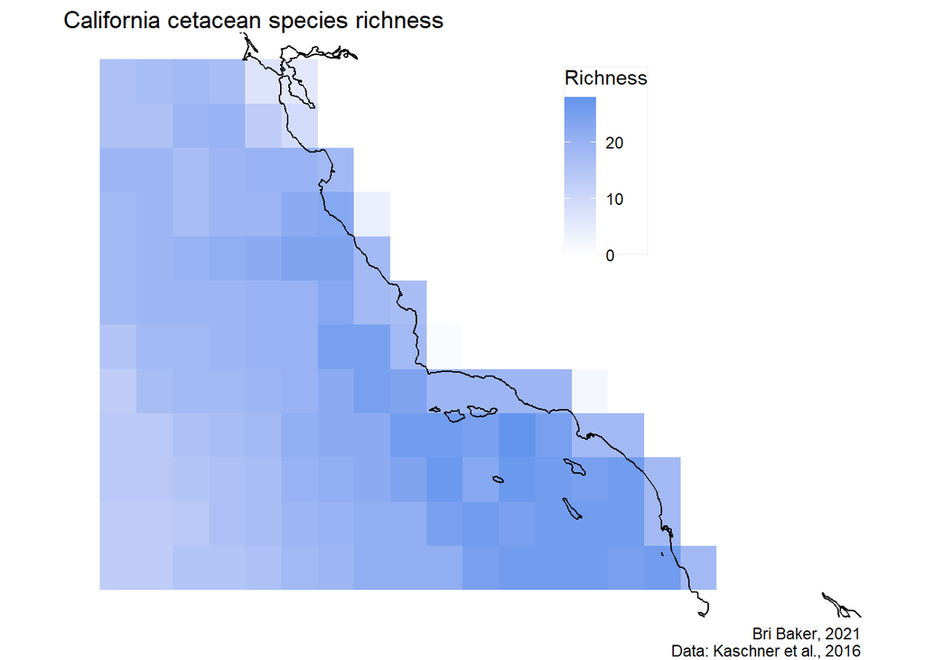

```r
# make ggplot-able
ca_richness <- raster::rasterToPoints(ca_cet_rich) %>%
  as.data.frame() %>%
  rename("richness" = "layer")

# plot
ggplot()+
  geom_raster(data = ca_richness, aes(x = x,
                                      y = y,
                                      fill = richness)) +
  geom_sf(data = coastline) +
  coord_sf(xlim = c(-125, -115), ylim = c(32, 38))+
  scale_fill_gradient(low = 'white', high = 'cornflowerblue') +
  labs(fill = "Richness",
       title = "California cetacean species richness",
       caption = "Bri Baker, 2021\nData: Kaschner et al., 2016") +
  theme_void()+
  theme(legend.position = c(0.68, 0.78), # move legend
        legend.background = element_rect(fill="white",
                                         linetype = "solid", color = "whitesmoke"))
```

## Data and Package Citation

Hijmans, Robert J. (2020). raster: Geographic Data Analysis and Modeling. R package version 3.3-13. https://CRAN.R-project.org/package=raster

Kaschner, K., Rius-Barile, J., Kesner-Reyes, K., Garilao, C., Kullander, S., Rees, T., & Froese, R. (2016). AquaMaps: Predicted range maps for aquatic species. www.aquamaps.org

Müller, Kirill (2020). here: A Simpler Way to Find Your Files. R package version 1.0.0. https://CRAN.R-project.org/package=here

Pebesma, E., 2018. Simple Features for R: Standardized Support for Spatial Vector Data. The R Journal 10 (1), 439-446, https://doi.org/10.32614/RJ-2018-009

South, Andy (2017). rnaturalearth: World Map Data from Natural Earth. R package version 0.1.0. https://CRAN.R-project.org/package=rnaturalearth

Wickham et al., (2019). Welcome to the tidyverse. Journal of Open Source Software, 4(43), 1686, https://doi.org/10.21105/joss.01686